# Extracting features

jhms

01/04/2020

Before we can process our samples, we need to create a list of which samples we want to process. We can get a list (or, more acurately *a vector*) of files using Sys.glob, which allows wild-card matching of files. As we want to bind some more data to these filenames, we convert the vector into a data frame. We’ve been told the following about our samples - Samples differ on three levels - Soil type (3 types) - Biological replicate (3 per soil type) - Technical replicate (3 per biological replicate) - The samples were run in order of soil type, biological rep, technical rep. E.g. the first sample is Soil A, biorep 1, techrep 1, the next is Soil A, biorep 1, techrep 1, and so on, with the last being Soil O, biorep 3, techrep 3. - The order of soil is A (Agricultural), F (Forest), O (Organic)

We can repeat an element of a vector using the rep() function. E.g:

```r
rep('A', 3)
```

```
## [1] "A" "A" "A"
```

gives us A A A A vector itself can also be repeated e.g.:

```r
rep(c('A','B'), 3)
```

```
## [1] "A" "B" "A" "B" "A" "B"
```

gives us A B A B A B. This can also be done by element:

```r
rep(c('A','B'), each=3)
```

```
## [1] "A" "A" "A" "B" "B" "B"
```

which gets us A A A B B B

Given the structure below, how can we fill in the missing annotations (i.e. replace the 0s)?

```r
samples<-as.data.frame(Sys.glob("SUM/*.mzML"), stringsAsFactors = F)
colnames(samples)[1]<-"filename"
samples$soil<-0
samples$biorep<-0
samples$techrep<-0
samples$bio_id<-paste0(samples$soil,samples$biorep)
samples$tech_id<-paste0(samples$bio_id,".",samples$techrep)
samples
```

```
##                      filename soil biorep techrep bio_id tech_id
## 1  SUM/HW-290120-007.sum.mzML    0      0       0     00    00.0
## 2  SUM/HW-290120-008.sum.mzML    0      0       0     00    00.0
## 3  SUM/HW-290120-009.sum.mzML    0      0       0     00    00.0
## 4  SUM/HW-290120-010.sum.mzML    0      0       0     00    00.0
## 5  SUM/HW-290120-011.sum.mzML    0      0       0     00    00.0
## 6  SUM/HW-290120-012.sum.mzML    0      0       0     00    00.0
## 7  SUM/HW-290120-013.sum.mzML    0      0       0     00    00.0
## 8  SUM/HW-290120-014.sum.mzML    0      0       0     00    00.0
## 9  SUM/HW-290120-015.sum.mzML    0      0       0     00    00.0
## 10 SUM/HW-290120-016.sum.mzML    0      0       0     00    00.0
## 11 SUM/HW-290120-017.sum.mzML    0      0       0     00    00.0
## 12 SUM/HW-290120-018.sum.mzML    0      0       0     00    00.0
## 13 SUM/HW-290120-019.sum.mzML    0      0       0     00    00.0
## 14 SUM/HW-290120-020.sum.mzML    0      0       0     00    00.0
## 15 SUM/HW-290120-021.sum.mzML    0      0       0     00    00.0
## 16 SUM/HW-290120-022.sum.mzML    0      0       0     00    00.0
## 17 SUM/HW-290120-023.sum.mzML    0      0       0     00    00.0
## 18 SUM/HW-290120-024.sum.mzML    0      0       0     00    00.0
## 19 SUM/HW-290120-025.sum.mzML    0      0       0     00    00.0
## 20 SUM/HW-290120-026.sum.mzML    0      0       0     00    00.0
## 21 SUM/HW-290120-027.sum.mzML    0      0       0     00    00.0
## 22 SUM/HW-290120-028.sum.mzML    0      0       0     00    00.0
## 23 SUM/HW-290120-029.sum.mzML    0      0       0     00    00.0
## 24 SUM/HW-290120-030.sum.mzML    0      0       0     00    00.0
## 25 SUM/HW-290120-031.sum.mzML    0      0       0     00    00.0
## 26 SUM/HW-290120-032.sum.mzML    0      0       0     00    00.0
## 27 SUM/HW-290120-033.sum.mzML    0      0       0     00    00.0
```

**Expected output**

|  | filename | sum_filename | soil | biorep | techrep | bio_id | tech_id |
| --- | --- | --- | --- | --- | --- | --- | --- |
| 1 | RAW/HW-290120-007.mzML | SUM/HW-290120-007.sum.mzML | A | 1 | 1 | A1 | A1.1 |
| 2 | RAW/HW-290120-008.mzML | SUM/HW-290120-008.sum.mzML | A | 1 | 2 | A1 | A1.2 |
| 3 | RAW/HW-290120-009.mzML | SUM/HW-290120-009.sum.mzML | A | 1 | 3 | A1 | A1.3 |
| 4 | RAW/HW-290120-010.mzML | SUM/HW-290120-010.sum.mzML | A | 2 | 1 | A2 | A2.1 |
| 5 | RAW/HW-290120-011.mzML | SUM/HW-290120-011.sum.mzML | A | 2 | 2 | A2 | A2.2 |
| 6 | RAW/HW-290120-012.mzML | SUM/HW-290120-012.sum.mzML | A | 2 | 3 | A2 | A2.3 |
| 7 | RAW/HW-290120-013.mzML | SUM/HW-290120-013.sum.mzML | A | 3 | 1 | A3 | A3.1 |
| 8 | RAW/HW-290120-014.mzML | SUM/HW-290120-014.sum.mzML | A | 3 | 2 | A3 | A3.2 |
| 9 | RAW/HW-290120-015.mzML | SUM/HW-290120-015.sum.mzML | A | 3 | 3 | A3 | A3.3 |
| 10 | RAW/HW-290120-016.mzML | SUM/HW-290120-016.sum.mzML | F | 1 | 1 | F1 | F1.1 |
| 11 | RAW/HW-290120-017.mzML | SUM/HW-290120-017.sum.mzML | F | 1 | 2 | F1 | F1.2 |
| 12 | RAW/HW-290120-018.mzML | SUM/HW-290120-018.sum.mzML | F | 1 | 3 | F1 | F1.3 |
| 13 | RAW/HW-290120-019.mzML | SUM/HW-290120-019.sum.mzML | F | 2 | 1 | F2 | F2.1 |
| 14 | RAW/HW-290120-020.mzML | SUM/HW-290120-020.sum.mzML | F | 2 | 2 | F2 | F2.2 |
| 15 | RAW/HW-290120-021.mzML | SUM/HW-290120-021.sum.mzML | F | 2 | 3 | F2 | F2.3 |
| 16 | RAW/HW-290120-022.mzML | SUM/HW-290120-022.sum.mzML | F | 3 | 1 | F3 | F3.1 |
| 17 | RAW/HW-290120-023.mzML | SUM/HW-290120-023.sum.mzML | F | 3 | 2 | F3 | F3.2 |
| 18 | RAW/HW-290120-024.mzML | SUM/HW-290120-024.sum.mzML | F | 3 | 3 | F3 | F3.3 |
| 19 | RAW/HW-290120-025.mzML | SUM/HW-290120-025.sum.mzML | O | 1 | 1 | O1 | O1.1 |
| 20 | RAW/HW-290120-026.mzML | SUM/HW-290120-026.sum.mzML | O | 1 | 2 | O1 | O1.2 |
| 21 | RAW/HW-290120-027.mzML | SUM/HW-290120-027.sum.mzML | O | 1 | 3 | O1 | O1.3 |
| 22 | RAW/HW-290120-028.mzML | SUM/HW-290120-028.sum.mzML | O | 2 | 1 | O2 | O2.1 |
| 23 | RAW/HW-290120-029.mzML | SUM/HW-290120-029.sum.mzML | O | 2 | 2 | O2 | O2.2 |
| 24 | RAW/HW-290120-030.mzML | SUM/HW-290120-030.sum.mzML | O | 2 | 3 | O2 | O2.3 |
| 25 | RAW/HW-290120-031.mzML | SUM/HW-290120-031.sum.mzML | O | 3 | 1 | O3 | O3.1 |
| 26 | RAW/HW-290120-032.mzML | SUM/HW-290120-032.sum.mzML | O | 3 | 2 | O3 | O3.2 |
| 27 | RAW/HW-290120-033.mzML | SUM/HW-290120-033.sum.mzML | O | 3 | 3 | O3 | O3.3 |

**Solution**

```r
samples$soil<-c(rep('A',9),rep('F',9),rep('O',9))
samples$biorep<-c(rep(rep(1:3, each=3),3))
samples$techrep<-c(rep(1:3,9))
samples$bio_id<-paste0(samples$soil,samples$biorep)
samples$tech_id<-paste0(samples$bio_id,".",samples$techrep)
samples
```

```
##                      filename soil biorep techrep bio_id tech_id
## 1  SUM/HW-290120-007.sum.mzML    A      1       1     A1    A1.1
## 2  SUM/HW-290120-008.sum.mzML    A      1       2     A1    A1.2
## 3  SUM/HW-290120-009.sum.mzML    A      1       3     A1    A1.3
## 4  SUM/HW-290120-010.sum.mzML    A      2       1     A2    A2.1
## 5  SUM/HW-290120-011.sum.mzML    A      2       2     A2    A2.2
## 6  SUM/HW-290120-012.sum.mzML    A      2       3     A2    A2.3
## 7  SUM/HW-290120-013.sum.mzML    A      3       1     A3    A3.1
## 8  SUM/HW-290120-014.sum.mzML    A      3       2     A3    A3.2
## 9  SUM/HW-290120-015.sum.mzML    A      3       3     A3    A3.3
## 10 SUM/HW-290120-016.sum.mzML    F      1       1     F1    F1.1
## 11 SUM/HW-290120-017.sum.mzML    F      1       2     F1    F1.2
## 12 SUM/HW-290120-018.sum.mzML    F      1       3     F1    F1.3
## 13 SUM/HW-290120-019.sum.mzML    F      2       1     F2    F2.1
## 14 SUM/HW-290120-020.sum.mzML    F      2       2     F2    F2.2
## 15 SUM/HW-290120-021.sum.mzML    F      2       3     F2    F2.3
## 16 SUM/HW-290120-022.sum.mzML    F      3       1     F3    F3.1
## 17 SUM/HW-290120-023.sum.mzML    F      3       2     F3    F3.2
## 18 SUM/HW-290120-024.sum.mzML    F      3       3     F3    F3.3
## 19 SUM/HW-290120-025.sum.mzML    O      1       1     O1    O1.1
## 20 SUM/HW-290120-026.sum.mzML    O      1       2     O1    O1.2
## 21 SUM/HW-290120-027.sum.mzML    O      1       3     O1    O1.3
## 22 SUM/HW-290120-028.sum.mzML    O      2       1     O2    O2.1
## 23 SUM/HW-290120-029.sum.mzML    O      2       2     O2    O2.2
## 24 SUM/HW-290120-030.sum.mzML    O      2       3     O2    O2.3
## 25 SUM/HW-290120-031.sum.mzML    O      3       1     O3    O3.1
## 26 SUM/HW-290120-032.sum.mzML    O      3       2     O3    O3.2
## 27 SUM/HW-290120-033.sum.mzML    O      3       3     O3    O3.3
```

```r
suppressWarnings(rawdata<-importMzMl(samples$filename, centroided = F, verbose=F))
length(rawdata)
```

```
## [1] 27
```

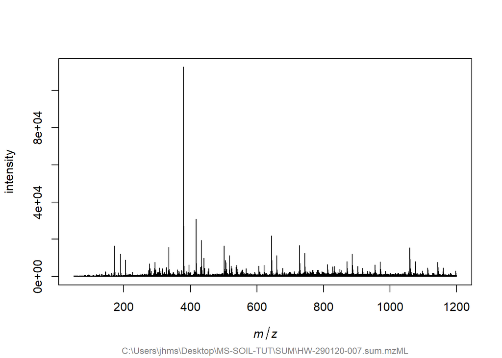

```r
mzroi<-c(200,210)
inroi<-c(0,10000)
plot(rawdata[[1]])
```

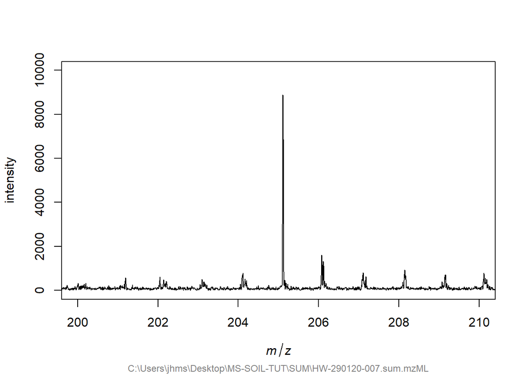

```r
plot(rawdata[[1]], xlim=mzroi, ylim=inroi)
```

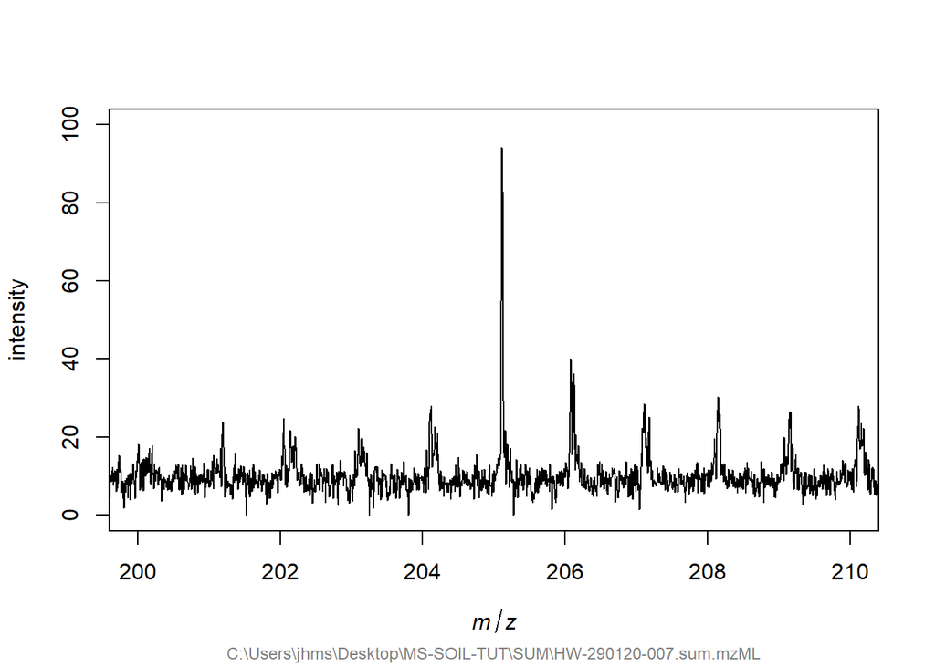

```r
spectra<-transformIntensity(rawdata, method="sqrt")
plot(spectra[[1]], xlim=mzroi, ylim=sqrt(inroi))
```

How much to smooth? Rule of thumb, as many data points in the smooth as there are in the top half of the peak.

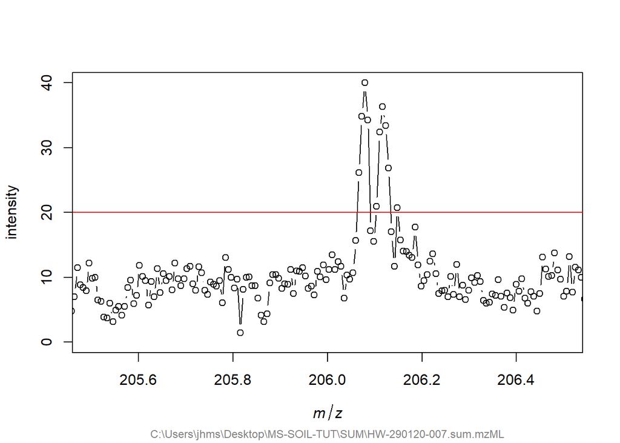

```r
plot(spectra[[1]], xlim=c(205.5,206.5), ylim=c(0,40), type='b')
abline(h=20, col='red')
```

Assuming the signal between 206.0 and 206.2 is a single peak, we count roughly 11 data points between when it first goes above 20 to when it last drops below 20 counts. For the Savitzky golay filter, we specify the number of points to include before and after the data point being calculated (the halfwindow size). The total window is 2 * halfwindow + 1 (the data point itself). If we have a full window of 11, the halfwindow size is therefore 5.

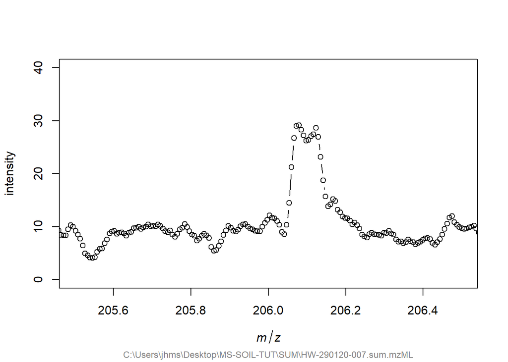

```r
testspectrumhw5<-smoothIntensity(spectra[[1]], method="SavitzkyGolay", halfWindowSize=5)
plot(testspectrumhw5, xlim=c(205.5,206.5), ylim=c(0,40), type='b')
```

This still preserves part of the ‘twin’ peak shape. If we increase the smoothing further, we start to lose this information:

```r
testspectrumhw11<-smoothIntensity(spectra[[1]], method="SavitzkyGolay", halfWindowSize=11)
```

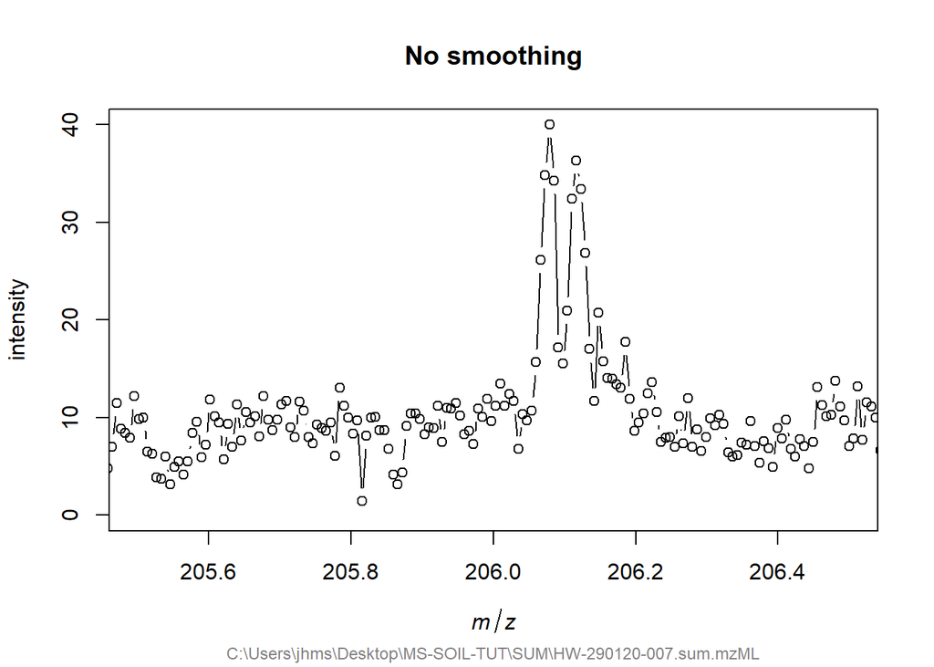

```r
plot(spectra[[1]], xlim=c(205.5,206.5), ylim=c(0,40), type='b', main="No smoothing")
```

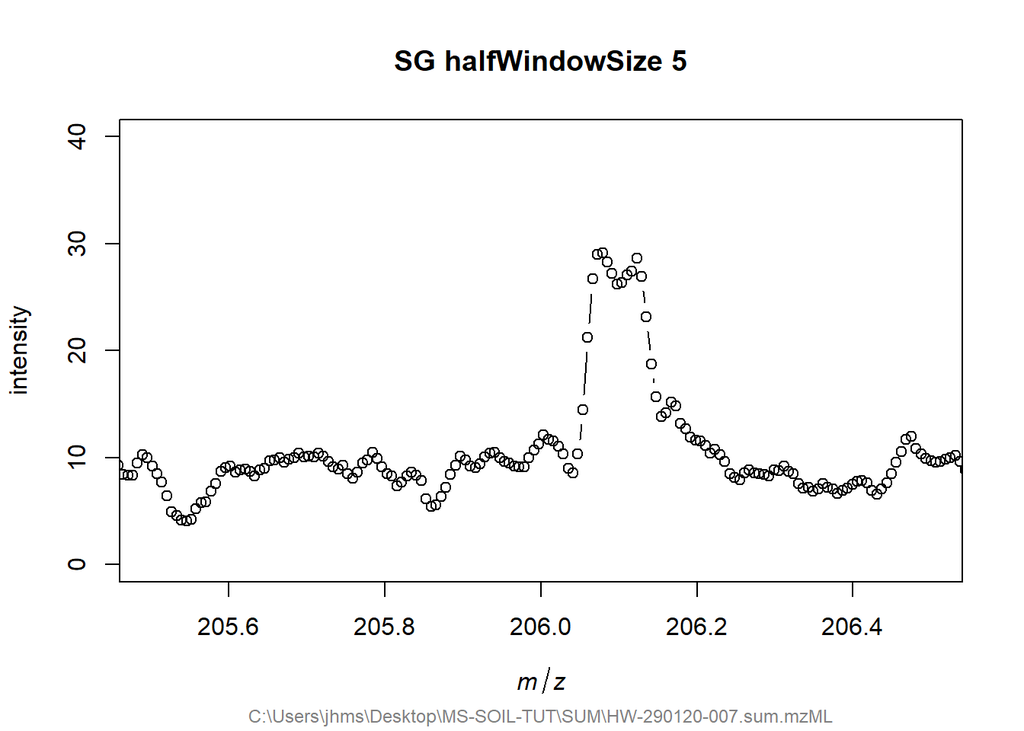

```r
plot(testspectrumhw5, xlim=c(205.5,206.5), ylim=c(0,40), type='b', main="SG halfWindowSize 5")
```

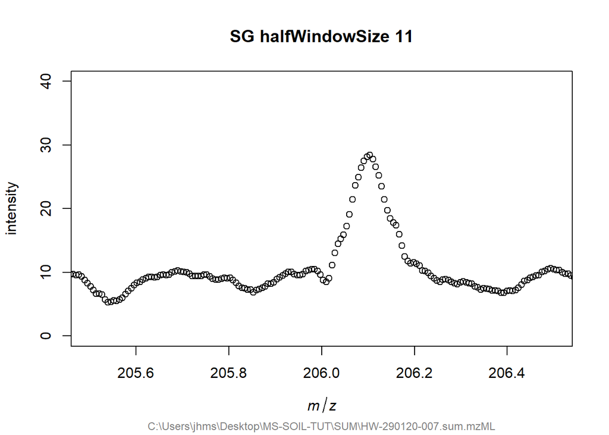

```r
plot(testspectrumhw11, xlim=c(205.5,206.5), ylim=c(0,40), type='b', main="SG halfWindowSize 11")
```

The halfwindow of 5 looks like it will smooth the data, without losing all the detail. Here’s a slightly more zoomed out view and the same view for the non-smoothed data.

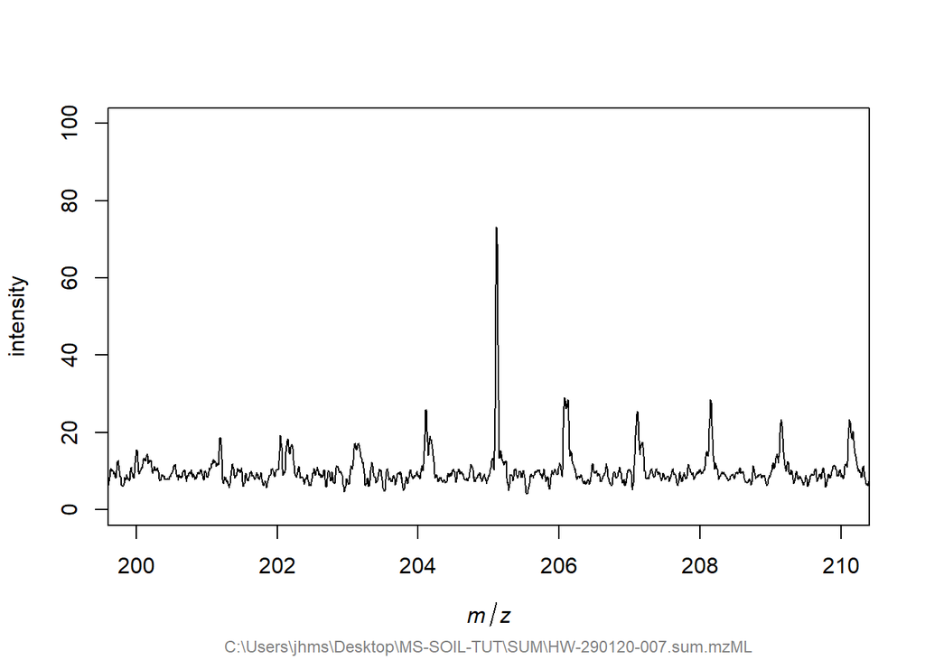

```r
plot(testspectrumhw5, xlim=mzroi, ylim=sqrt(inroi), type='l')
```

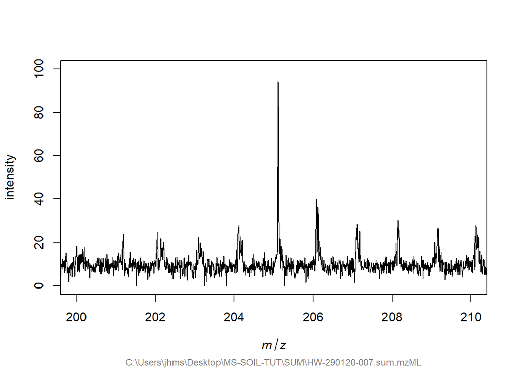

```r
plot(spectra[[1]], xlim=mzroi, ylim=sqrt(inroi), type='l')
```

We stick with a halfWindowSize of 5, and apply it to all spectra.

```r
spectra<-smoothIntensity(spectra, method="SavitzkyGolay", halfWindowSize=5)
```

Next, what do baselines look like?

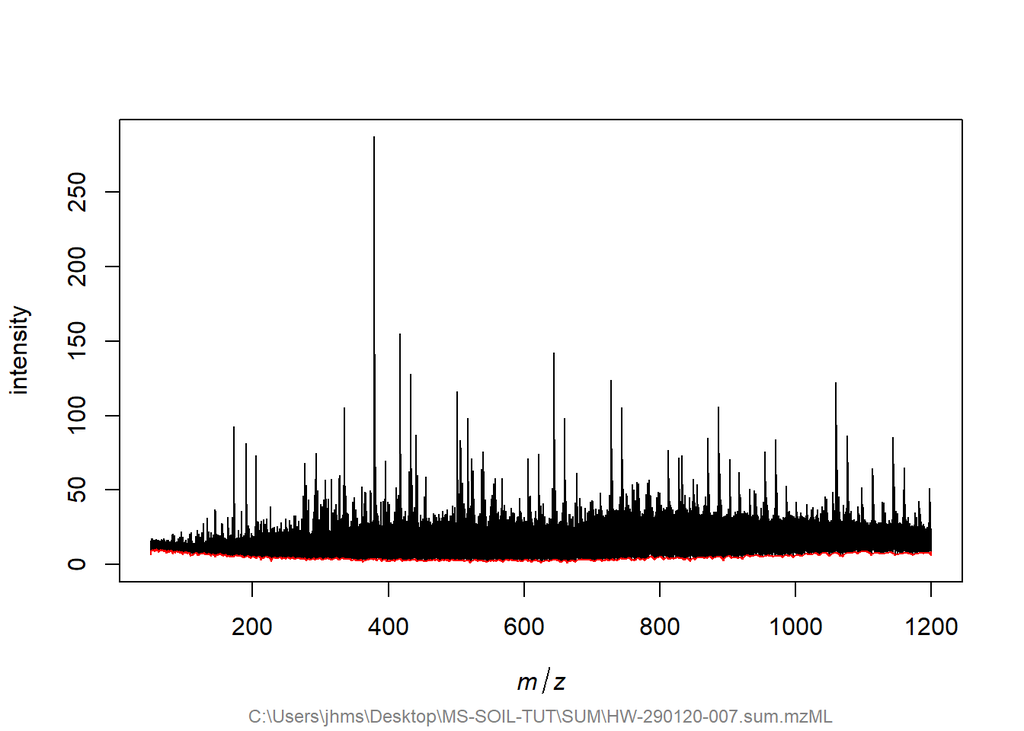

```r
baselinetest <- estimateBaseline(spectra[[1]], method="SNIP", iterations=100)
plot(spectra[[1]])
lines(baselinetest, col='red')
```

It looks a little bumpy. In close up:

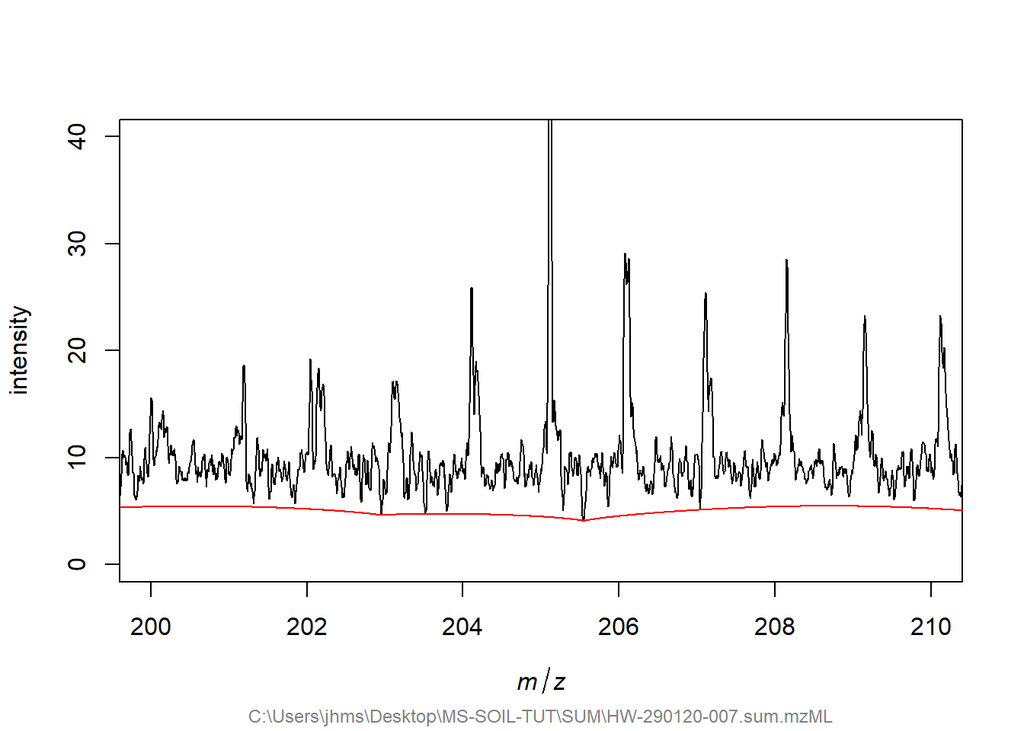

```r
plot(spectra[[1]], xlim=mzroi, ylim=c(0,40))
lines(baselinetest, col='red')
```

Increasing the interationcount makes it less sensitive:

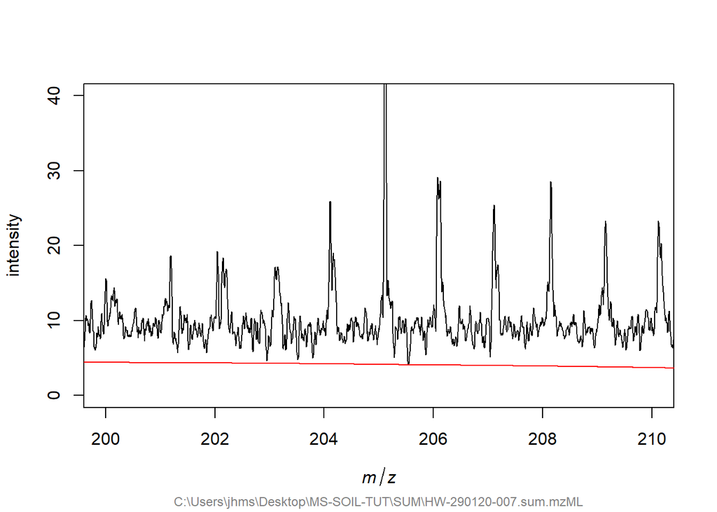

```r
baselinetest <- estimateBaseline(spectra[[1]], method="SNIP", iterations=250)
plot(spectra[[1]], xlim=mzroi, ylim=c(0,40))
lines(baselinetest, col='red')
```

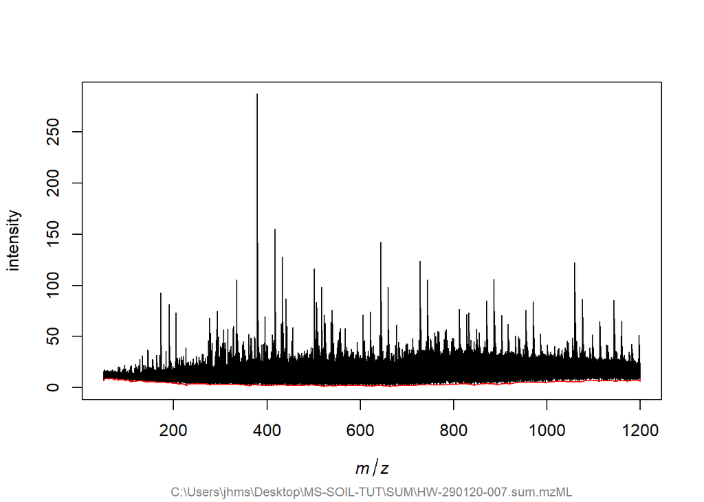

```r
plot(spectra[[1]])
lines(baselinetest, col='red')
```

As it now looks smoother, we apply these settings for baseline removal. As an output to check what’s happened, we include a couple of plots.

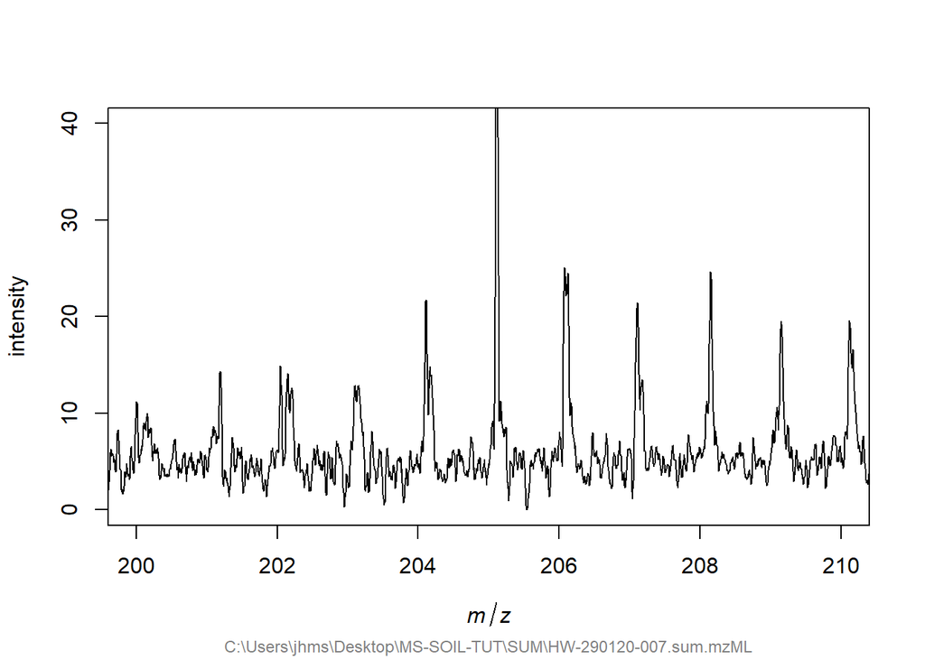

```r
spectra <- removeBaseline(spectra, method="SNIP", iterations=250)
plot(spectra[[1]], xlim=mzroi, ylim=c(0,40))
```

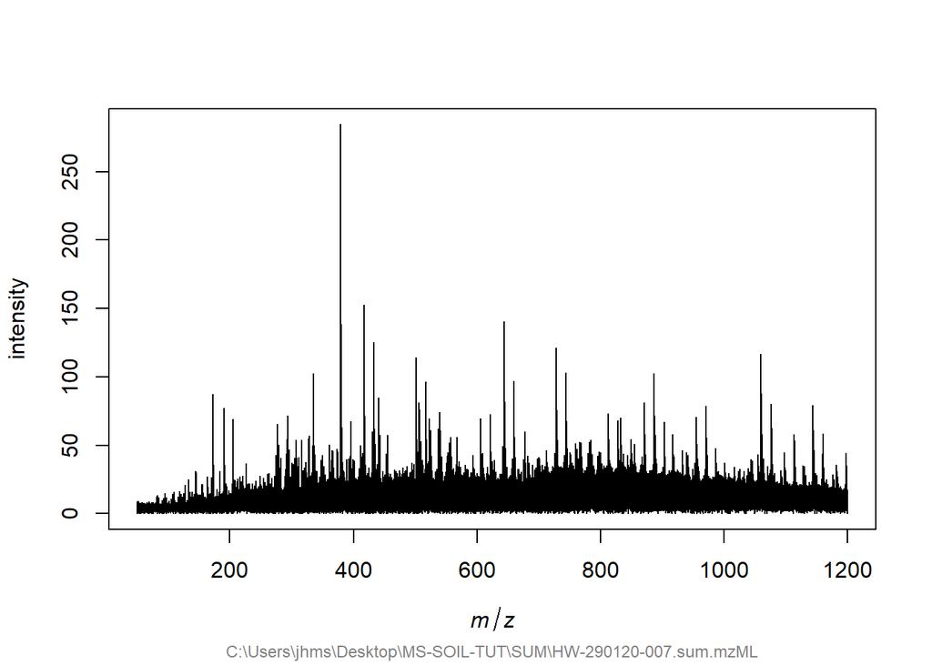

```r
plot(spectra[[1]])
```

In addition, we also want normalise for overall intensity, or total ion count. We can get the sums of the intensities to check for big differences

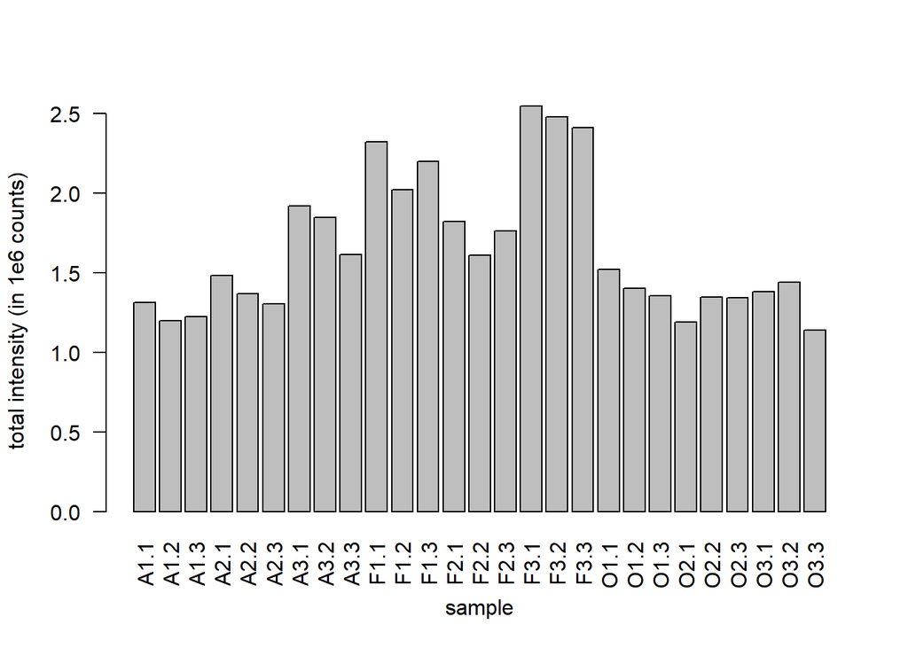

```r
intensities<-sapply(spectra, function(spectrum){sum(intensity(spectrum))})
barplot(intensities/1e6, names.arg = samples$tech_id, xlab = "sample", ylab = "total intensity (in 1e6 counts)", las=2)
```

For the actual calibration, and comparison afterwards:

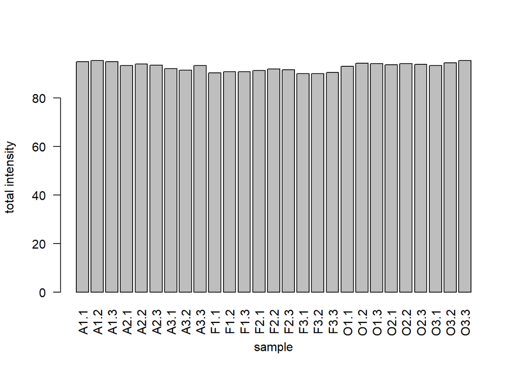

```r
spectra <- calibrateIntensity(spectra, method="TIC")
intensities<-sapply(spectra, function(spectrum){sum(intensity(spectrum))})
barplot(intensities, names.arg = samples$tech_id, xlab = "sample", ylab = "total intensity", las=2)
```

Next we call some tentative peaks and see how well our samples are aligned

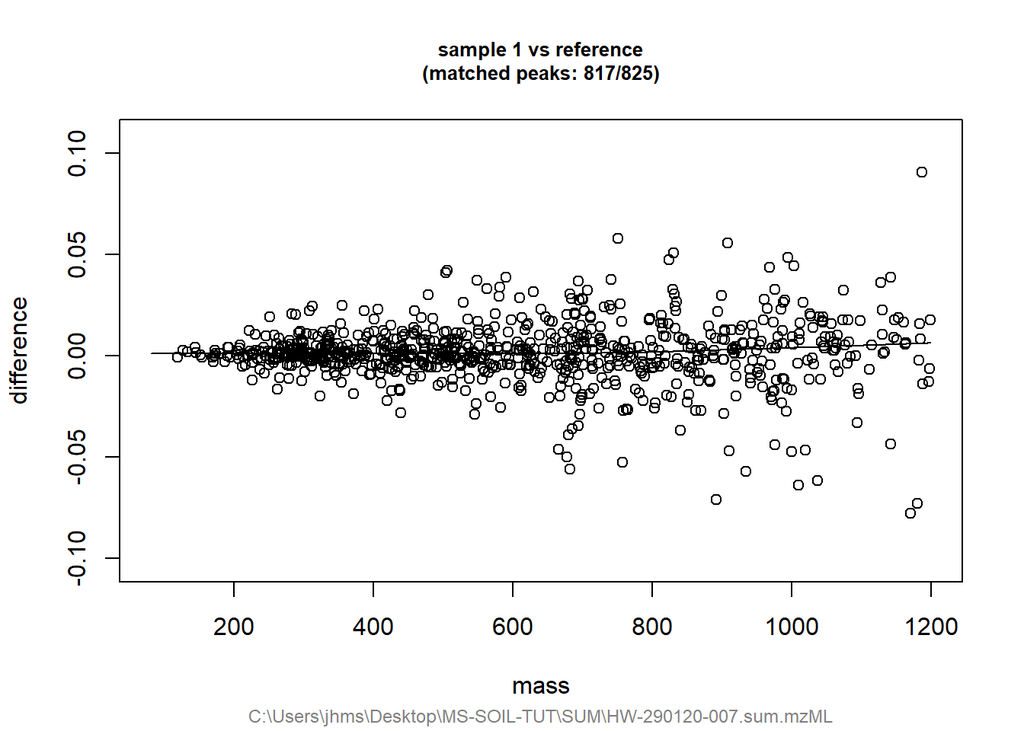

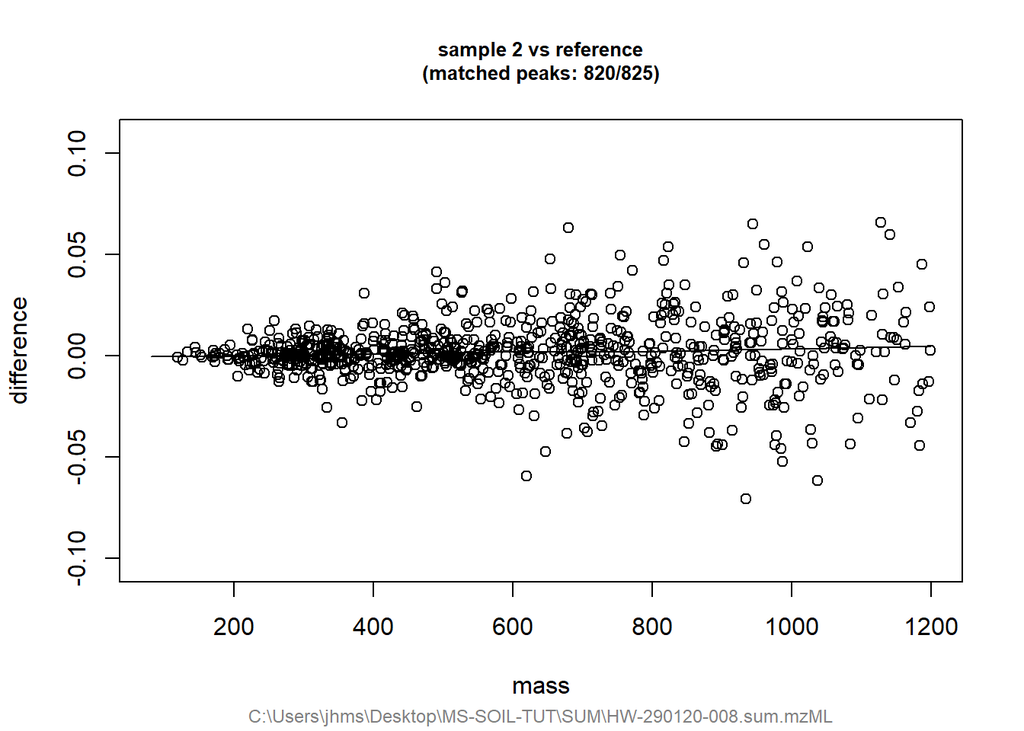

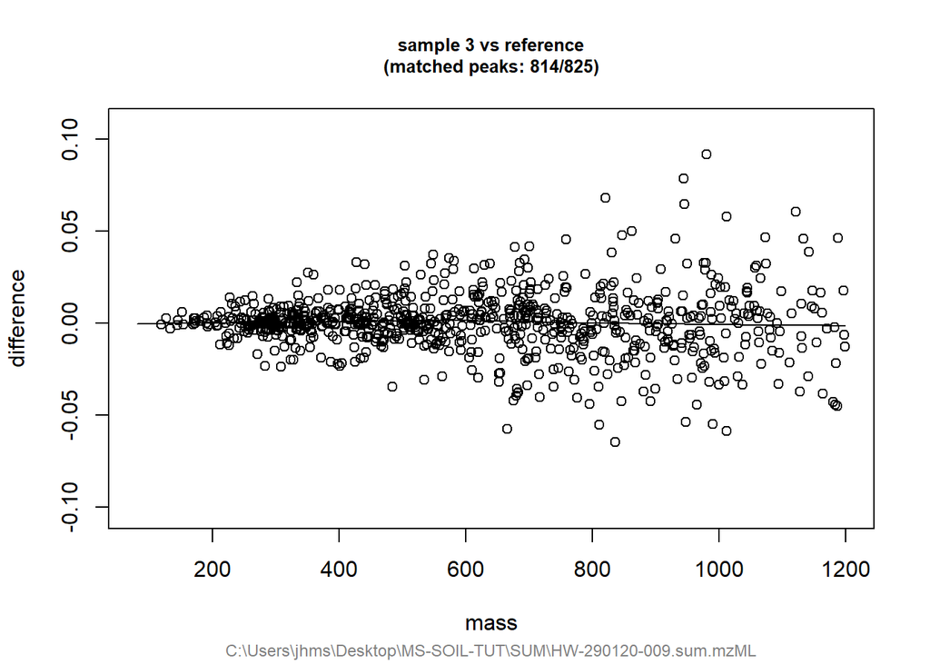

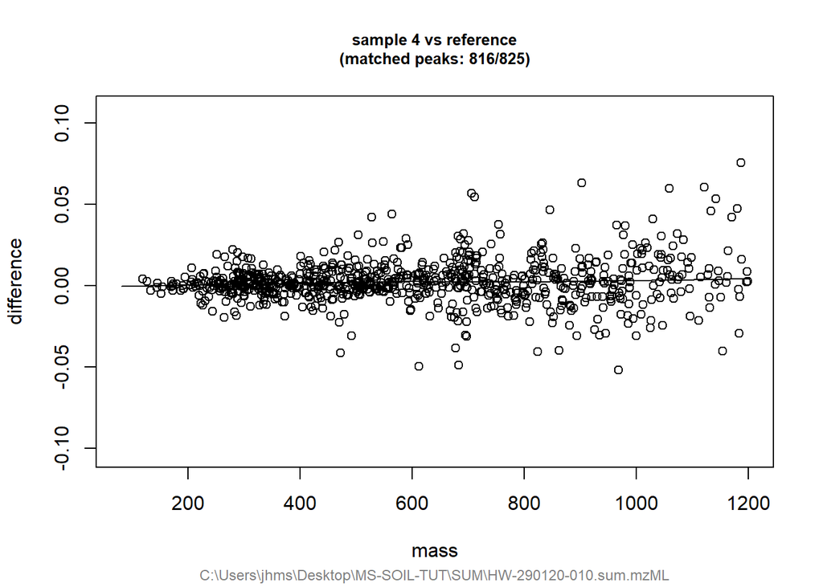

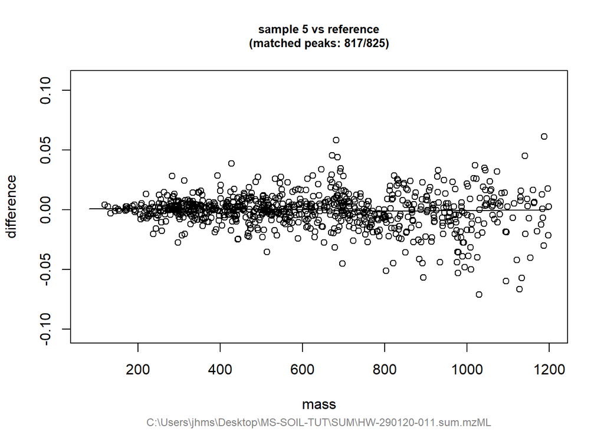

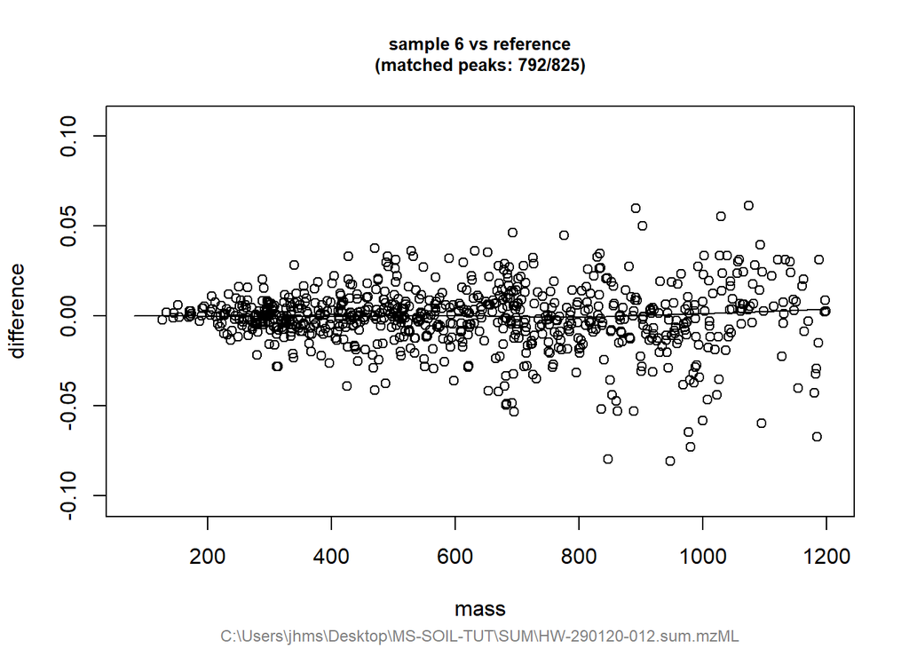

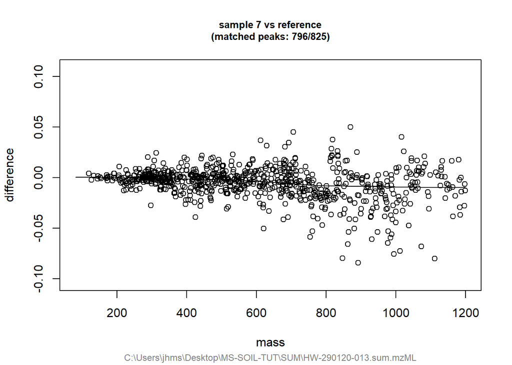

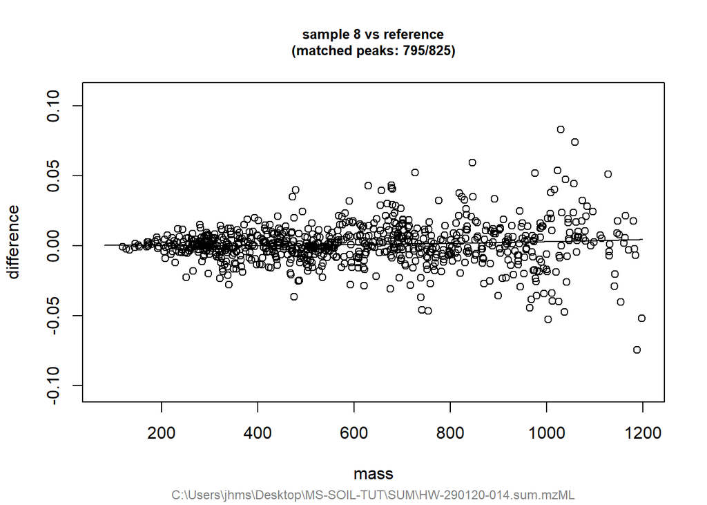

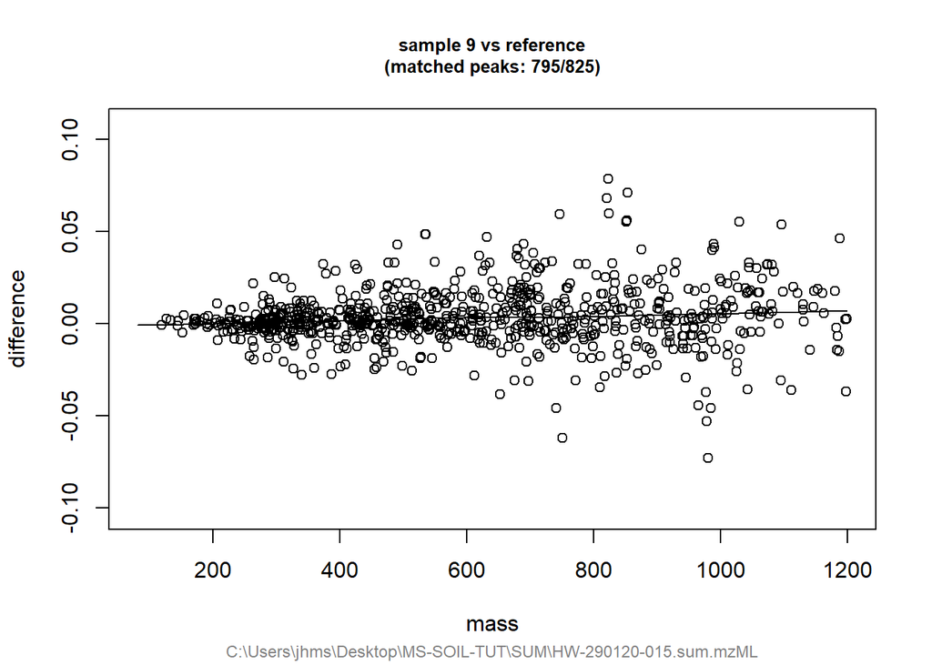

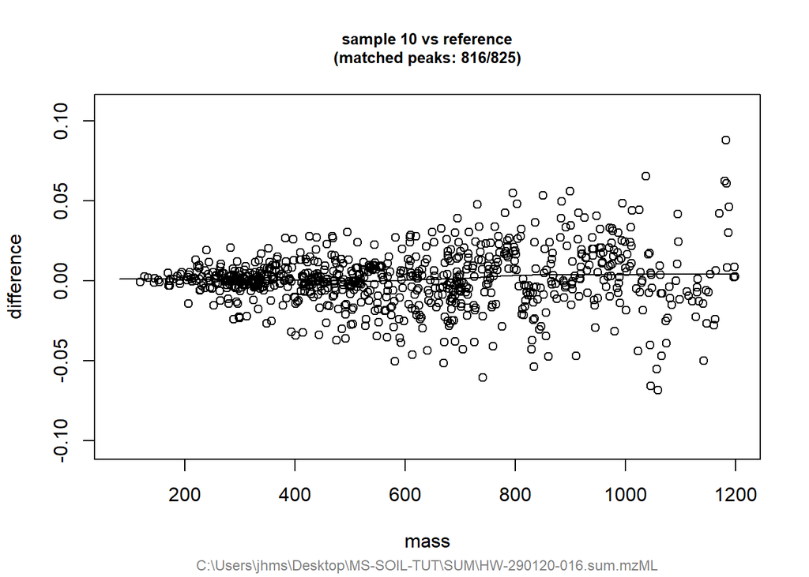

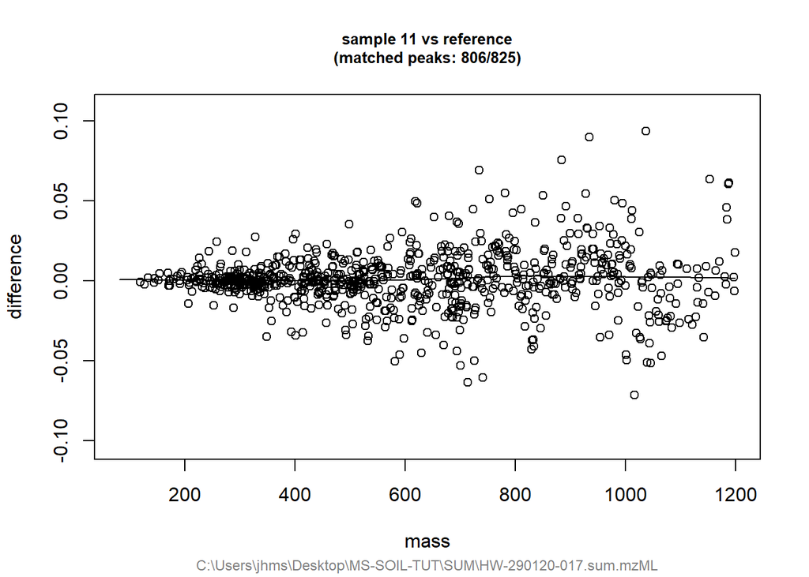

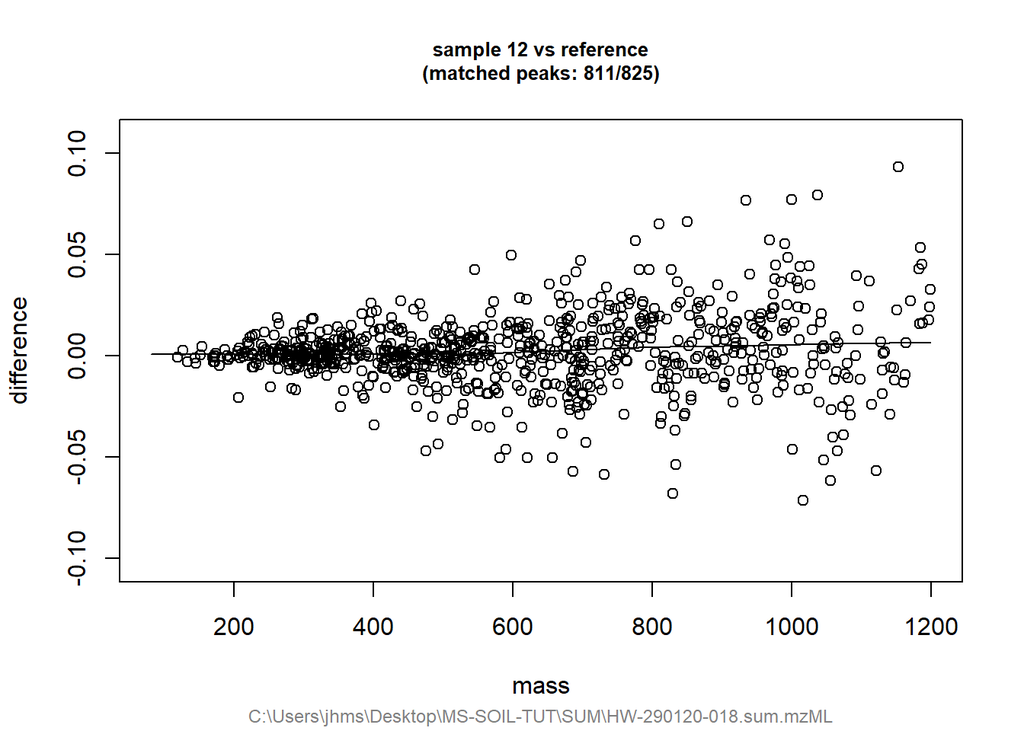

[15 more figures not shown]

```r
testpeaks<-detectPeaks(spectra, halfWindowSize=5, SNR=3)
warps<-determineWarpingFunctions(testpeaks, plot = T, tolerance = 100e-6)
```